# Module 4: Regularization

Sankalp Biswal

2024-02-02

# Introduction

In the field of machine learning, model regularization is a critical technique used to prevent overfitting, improve model generalization, and handle multicollinearity. This document explores the application of Ridge and LASSO regression — two popular regularization methods — and compares their performance to stepwise feature selection on the `College` dataset from the `ISLR` library. The aim is to identify which model provides the best fit for predicting the graduation rate (`Grad.Rate`) of colleges.

## Importing Libraries

```r
list.of.packages <- c( "ggplot2", "pls", "Matrix", "caTools", "glmnet")
new.packages <- list.of.packages[!(list.of.packages %in% installed.packages()[,"Package"])]
if(length(new.packages)) install.packages(new.packages)
require(glmnet)
require(caTools)
#tinytex::install_tinytex()
library(MASS)  # For stepwise selection
library(caret)  # For RMSE calculation
library(ISLR)
library(knitr)
library(kableExtra)
```

## Importing Dataset

```r
df <- College
```

# Ridge regression

## 1. Split the data into a train and test set

```r
set.seed(123)
trainIndex <- sort(sample(x = nrow(df), size = nrow(df) * 0.7))
train <- df[trainIndex,]
test <- df[-trainIndex,]
```

## 2. Use the cv.glmnet function to estimate the lambda.min and lambda.1se values. Compare and discuss the values.

- Code below has been sourced from 4b_Regularization.Rmd

```r
set.seed(123)

lambda_seq <- 10^seq(2, -2, by = -.1)


train_x     <- model.matrix(Grad.Rate ~. , train)[,-1]
train_y      <- train$Grad.Rate
test_x     <- model.matrix(Grad.Rate ~. , test)[,-1]
test_y      <- test$Grad.Rate

# Standardize features for Ridge regression (OpenAI,2024)
train_x_scaled <- scale(train_x)
test_x_scaled <- scale(test_x, center = attr(train_x_scaled, "scaled:center"), scale = attr(train_x_scaled, "scaled:scale"))

# Finding best value of lamda using cross validation

cv_output  <- cv.glmnet(train_x_scaled, train_y, alpha = 0, lambda = lambda_seq)

lambda.min <- cv_output$lambda.min
lambda.1se <- cv_output$lambda.1se

cat("lambda.min =", lambda.min)
```

```
## lambda.min = 1.258925
```

```r
cat("\n")
```

```r
cat("lamda.1se =", lambda.1se)
```

```
## lamda.1se = 12.58925
```

**`lambda.min`** (1.258925) represents the value of the regularization parameter that minimizes cross-validation error, offering the best predictive performance but potentially leading to a more complex model. **`lambda.1se`** (12.58925) is a more conservative choice, within one standard error of the minimum error, leading to a simpler, more interpretable model but possibly at the cost of slightly reduced predictive accuracy.

## 3. Plot the results from the cv.glmnet function and provide an interpretation. What does this plot tell us?

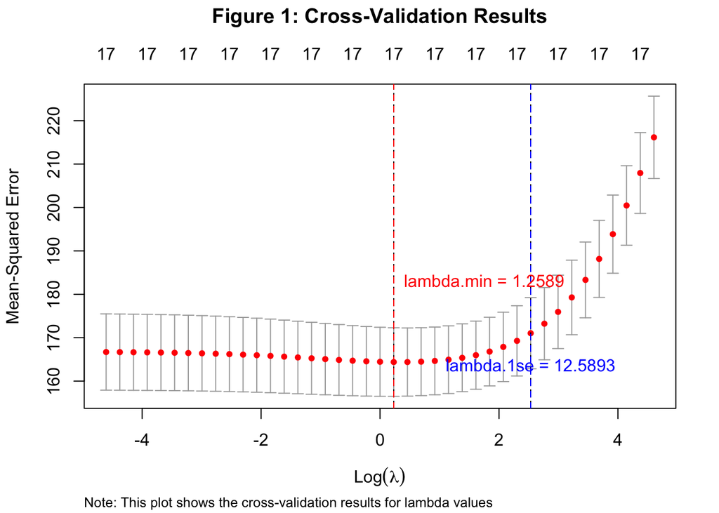

```r
plot(cv_output)

# Add a title
title("Figure 1: Cross-Validation Results", line = 3)

# Add vertical lines for lambda.min and lambda.1se
abline(v = log(cv_output$lambda.min), col = "red", lty = 2)
abline(v = log(cv_output$lambda.1se), col = "blue", lty = 2)

# Annotations with lambda.min and lambda.1se values
text(x = log(cv_output$lambda.min), y = par("usr")[4] * 0.8, labels = paste("lambda.min =", round(cv_output$lambda.min, 4)), pos = 4, col = "red")
text(x = log(cv_output$lambda.1se), y = par("usr")[4] * 0.7, labels = paste("lambda.1se =", round(cv_output$lambda.1se, 4)), pos = 3, col = "blue")

# Add a note at the bottom
mtext("Note: This plot shows the cross-validation results for lambda values", side = 1, line = 4, adj = 0, cex = 0.8)
```

**Figure 1:** This plot displays the cross-validation curve for different values of the regularization parameter, lambda (λ), plotted on a logarithmic scale (Log(λ)). The y-axis represents the mean squared error (MSE) from cross-validation.

**Interpretation:**

In summary, this plot helps in selecting a value for λ that balances model accuracy and complexity. It provides a visual tool to choose between the most accurate model (**`lambda.min`**) and a more regularized, simpler model (**`lambda.1se`**) that might perform slightly worse but could generalize better to unseen data.